# R script for generating Fig.4g and Extended Fig.5e

This script visualizes NES distributions with violin plots for common cancer types in HCMI and CCLE.

**Note**: OncoMatch results (HCMI/CCLE models vs. TCGA tumors) are required to run this code.

Please (1) download *supplementary_data_OncoMatchAnalysis_HCMI-vs-CCLE_bestModel-vs-TCGA.tar.gz* from *Files/Data/Transcriptional Data Analysis Subgroup Files/supplementary_data_oncomatch* on the HCMI synapse page, and(2) unzip it in the same directory as this script.

### Load libraries

Please install the libraries below if they were not preinstalled in your system.¶

```r
library(ggplot2)
library(pals)
library(plyr)
library(rstatix)
library(matrixStats)
```

#### Load input data (e.g. OncoMatch results) for violin plots:

```r
load(file="./supplementary_data_OncoMatchAnalysis_HCMI-vs-CCLE_bestModel-vs-TCGA/OncoMatch_output/nesTable-cohortSizeTable_modelHCMI-modelCCLE-vs-TCGA.rda")
```

This file contains two objects:

1. gdat: A table showing NES values for each model sample and its corresponding TCGA signature.
2. gdat_n: A table detailing the cohort sizes (number of models in HCMI/CCLE or number of tumors in TCGA) for cancer types.

#### Group label refining

Update group labels to include the size of each cohort using the gdat_n data:

```r
gdat$group = factor(gdat$group, levels=gdat_n$group)
levels(gdat$group) = paste(gdat_n$group, "\n(CCLE=", gdat_n$ccle, ";\nHCMI=",gdat_n$hcmi,";\nTCGA=",gdat_n$tcga,")", sep="")

gdat$set = factor(gdat$set, levels=c("hcmi","ccle","model"))
```

The dataset annotations are as follows: “hcmi” for HCMI models, “ccle” for CCLE models, and “model” for both HCMI and CCLE models.

#### Sorting group labes based on significance levels

Cancer types are sorted in decreasing order of statistical significance based on the Mann-Whitney U-test (one-tailed) to compare the median NES of HCMI models to CCLE models. A smaller p-value indicates greater significance for HCMI models having a higher median NES. This one-tailed U-test is used to arrange the cancer types in the Violin plot. Note that p-values from the two-tailed U-test are annotated with asterisks in the final plot.

```r
comp.pval = ddply(gdat,.(group), function(x) wilcox.test(x$nes[x$set=="hcmi"], x$nes[x$set=="ccle"], alternative="greater")$p.value)
comp.pval = comp.pval[order(comp.pval$V1),]
gdat$group = factor(gdat$group, levels=comp.pval$group)

head(comp.pval)
```

|  | group | V1 |
| --- | --- | --- |
| 4 | Brain Cancer\n(CCLE=83;\nHCMI=61;\nTCGA=670) | 2.597819e-118 |
| 1 | Colon-Colorectal Cancer\n(CCLE=70;\nHCMI=169;\nTCGA=644) | 1.673033e-62 |
| 13 | Kidney Cancer\n(CCLE=37;\nHCMI=10;\nTCGA=540) | 2.891678e-47 |
| 9 | Endometrial-Uterine Cancer\n(CCLE=40;\nHCMI=16;\nTCGA=553) | 1.849375e-22 |
| 10 | Breast Cancer\n(CCLE=61;\nHCMI=14;\nTCGA=1106) | 1.190888e-20 |
| 11 | Bladder Cancer\n(CCLE=36;\nHCMI=13;\nTCGA=412) | 3.006936e-16 |

#### Violin plots for NES distributions:

```r
gbox = ggplot(gdat) +
  geom_violin(aes(x=group, y=nes, fill=set), scale='width', alpha=0.25,
              width=0.7, lwd=0.25) +
  geom_boxplot(aes(x=group, y=nes, fill=set), width=0.25,
               outliers = FALSE,
               position=position_dodge(0.7), lwd=0.25, alpha=0.7) +
  geom_hline(yintercept = 0, col="grey30")+
  scale_fill_manual(values = c("orangered","dodgerblue","green3"),
                    breaks=c("hcmi","ccle","model"),
                    labels=c("HCMI","CCLE","all models"),
                    name=NULL) +
  scale_y_continuous(breaks=seq(-20,20,by=5)) +
  theme_bw()+
  theme(axis.text.x = element_text(angle=90, hjust=1, vjust=0.5),
        legend.position = c(0.5, 0.07),legend.direction="horizontal") +
  xlab(NULL) + ylab("OncoMatch [NES]")
```

#### Add p-values (two-tailed U-test; BH-adjusted) onto the box plots

Ralculate p-values for all pairs (i.e. hcmi-vs-ccle, hcmi-vs-model(hcmi+ccle), ccle-vs-model(hcmi+ccle)) in each cancer type:

```r
stat.test <- gdat %>%
  group_by(group) %>%
  wilcox_test(nes ~ set) %>%
  adjust_pvalue(method = "BH") %>%
  add_significance("p.adj")
## Remove instances that were not significant (adjust p>0.05):
stat.test = stat.test[stat.test$p.adj.signif!="ns",]
## Add xy positions
stat.test <- stat.test %>% add_xy_position(x = "group", dodge = 0.8)

stat.df = as.data.frame(stat.test)
## statistical significance between the best set and the combined models (HCMI+CCLE)
stat.df.model= ddply(stat.df,.(group), function(x){
  x$y.position = min(x$y.position)
  x=x[x$group2=="model",]  # The smaller p-value in the set (HCMI or CCLE) vs. combined model (HCMI+CCLE) comparisons implies a significant improvement in the median NES of the combined models (HCMI+CCLE).
  return(x)
})
## statistical significance between HCMI and CCLE models
stat.df.best= ddply(stat.df,.(group), function(x){
  x=x[x$group2!="model",] ## this only considers HCMI vs CCLE
  return(x)
})
## Identify a significant trend: (+) indicates the median NES of HCMI is greater than that of CCLE, while (-) indicates the opposite:
stat.df.best$sign =sapply(stat.df.best$group, function(k){
  r = sign(median(gdat$nes[gdat$group==k & gdat$set=="hcmi"])-
             median(gdat$nes[gdat$group==k & gdat$set=="ccle"]))
})
## For simplicity in visualization, statistical significance (asterisk) was annotated for the best set between HCMI and CCLE for each cancer type. The following details outline the x coordinates for the corresponding best sets across cancer types.
stat.df.best$xf = stat.df.best$xmin
stat.df.best$xf[stat.df.best$sign==-1] = stat.df.best$xmax[stat.df.best$sign==-1]
stat.df.best$y.position = stat.df.best$y.position-0.3
## Adjust y coordinates for significance annotations (asterisk symbols)
stat.df.model$y.position[stat.df.model$group1=="ccle"]=stat.df.model$y.position[stat.df.model$group1=="ccle"] + 0.3
## Add the significance annotation to the violin plot:
gbox_sig = gbox +
  geom_text(data=stat.df.best, aes(x=xf, y=y.position, label=p.adj.signif)) +
  geom_text(data=stat.df.model, aes(x=xmax, y=y.position, label=p.adj.signif))
# gbox_sig
```

#### Fig.4g. Violin plots for the top 11 significant cancer types, where the median NES of HCMI significantly exceeds that of CCLE.

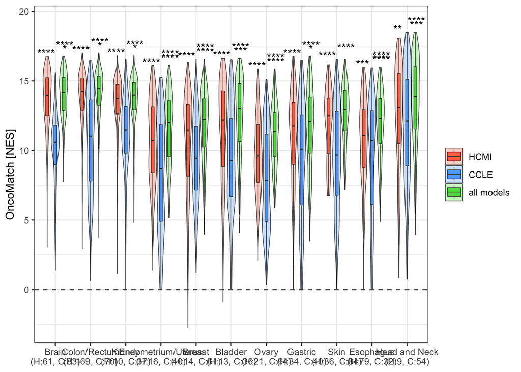

```r
gsub= gdat[is.element(gdat$group, levels(gdat$group)[1:11]),]
gsub$group= factor(gsub$group, levels= levels(gdat$group)[1:11])

# Formatting x-labels:
gdat_n2 = gdat_n[sapply(levels(gdat$group)[1:11],function(x) match(strsplit(x,split="\n")[[1]][1], gdat_n$group)),]
gdat_n2$label= gsub(" Cancer","", gdat_n2$group)
gdat_n2$label[grep("Esophageal", gdat_n2$label)]="Esophagus"
gdat_n2$label[grep("Ovarian", gdat_n2$label)]="Ovary"
gdat_n2$label[grep("Endometrial", gdat_n2$label)]="Endometrium/Uterus"
gdat_n2$label[grep("Colon", gdat_n2$label)]="Colon/Rectum"

gdat_n2$label2 = paste(gdat_n2$label, "\n(H:",gdat_n2$hcmi,", C:",gdat_n2$ccle,")",sep="")


# The NES Violin plots for the 11 cancer types:
gbox.topSig = ggplot(gsub) +
  geom_violin(aes(x=group, y=nes, fill=set), scale='width', alpha=0.25,
              width=0.7, lwd=0.25) +
  geom_boxplot(aes(x=group, y=nes, fill=set), width=0.25,
               outliers = FALSE,
               position=position_dodge(0.7), lwd=0.25, alpha=0.7) +
  geom_hline(yintercept = 0, col="grey30", linetype="dashed")+
  scale_fill_manual(values = c("orangered","dodgerblue","green3"),
                    breaks=c("hcmi","ccle","model"),
                    labels=c("HCMI","CCLE","all models"), name=NULL) +
  theme_bw()+
  scale_x_discrete(breaks=levels(gdat$group)[1:11], label=gdat_n2$label2) +
  # theme(axis.text.x = element_text(angle=90, hjust=1, vjust=0.5)) +
  xlab(NULL) + ylab("OncoMatch [NES]")


# statistical significance for the 11 cancer types
stat.df.model.sub= stat.df.model[is.element(stat.df.model$group, gsub$group),]
stat.df.best.sub= stat.df.best[is.element(stat.df.best$group, gsub$group),]

# The final NES violin plots with significance annotation for the 11 cancer types:
gbox_sig2 = gbox.topSig +
  geom_text(data=stat.df.best.sub, aes(x=xf, y=y.position, label=p.adj.signif)) +
  geom_text(data=stat.df.model.sub, aes(x=xmax, y=y.position, label=p.adj.signif))
gbox_sig2
```

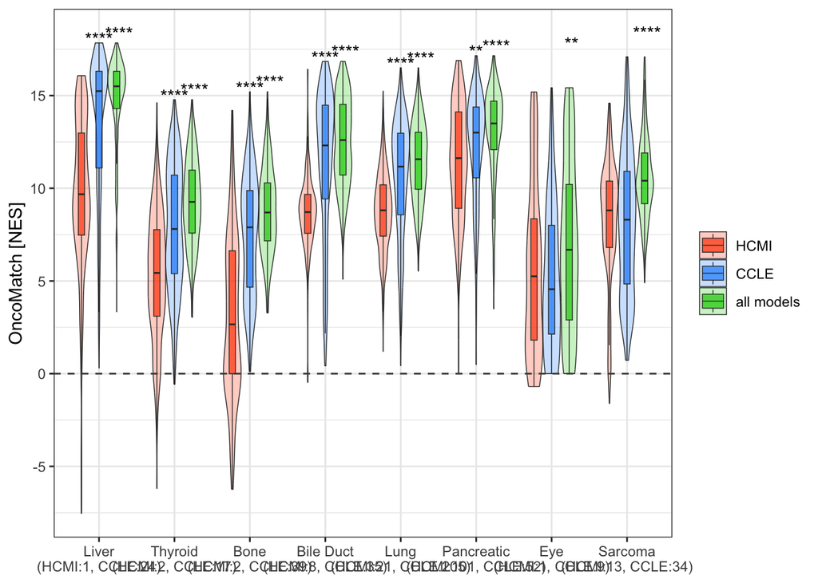

```r
gsub= gdat[is.element(gdat$group, levels(gdat$group)[12:19]),]
gsub$group= factor(gsub$group, levels= rev(levels(gdat$group)[12:19])) #The eight cancer types were re-sorted by the decreasing statistical significance of their greater NES median for CCLE compared to HCMI

gdat_n2 = gdat_n[sapply(levels(gsub$group),function(x) match(strsplit(x,split="\n")[[1]][1], gdat_n$group)),]
gdat_n2$label= gsub(" Cancer","", gdat_n2$group)
gdat_n2$label[grep("Esophageal", gdat_n2$label)]="Esophagus"
gdat_n2$label[grep("Ovarian", gdat_n2$label)]="Ovary"
gdat_n2$label[grep("Endometrial", gdat_n2$label)]="Endometrium/Uterus"
gdat_n2$label[grep("Colon", gdat_n2$label)]="Colon/Rectum"

gdat_n2$label2 = paste(gdat_n2$label, "\n(HCMI:",gdat_n2$hcmi,", CCLE:",gdat_n2$ccle,")",sep="")


# The NES Violin plots for the 8 cancer types:
gbox.topSig = ggplot(gsub) +
  geom_violin(aes(x=group, y=nes, fill=set), scale='width', alpha=0.25,
              width=0.7, lwd=0.25) +
  geom_boxplot(aes(x=group, y=nes, fill=set), width=0.25,
               outliers = FALSE,
               position=position_dodge(0.7), lwd=0.25, alpha=0.7) +
  geom_hline(yintercept = 0, col="grey30", linetype="dashed")+
  scale_fill_manual(values = c("orangered","dodgerblue","green3"),
                    breaks=c("hcmi","ccle","model"),
                    labels=c("HCMI","CCLE","all models"), name=NULL) +
  theme_bw()+
  scale_x_discrete(breaks=levels(gsub$group), label=gdat_n2$label2) +
  scale_y_continuous(breaks=seq(-10,20, by=5)) +
  # theme(axis.text.x = element_text(angle=90, hjust=1, vjust=0.5)) +
  xlab(NULL) + ylab("OncoMatch [NES]")


# statistical significance for the 8 cancer types
stat.df.model.sub= stat.df.model[match(levels(gsub$group), stat.df.model$group),]
stat.df.model.sub$xmax = rev(stat.df.model.sub$xmax) - 11

stat.df.best.sub= stat.df.best[match(levels(gsub$group), stat.df.best$group, nomatch=0),]
stat.df.best.sub$xf = 1:nrow(stat.df.best.sub)

# The final NES violin plots with significance annotation for the 8 cancer types:
gbox_sig2 = gbox.topSig +
  geom_text(data=stat.df.best.sub, aes(x=xf, y=y.position, label=p.adj.signif)) +
  geom_text(data=stat.df.model.sub, aes(x=xmax, y=y.position, label=p.adj.signif))
gbox_sig2
```